# reporte_final

División de Atención Ciudadana

**Reporte Final Práctica Profesional**

Juan Prado

[figure not shown]

Superintendencia de Educación Superior

**Nota:** Para ver más detalles, navegar verticalmente

# 1. Diagnóstico Disponibilidad Procesos Recurrentes

Solicitud interna

> Con el objetivo de tener un mejor conocimiento de la información que la División posee, se solicitó realizar un diagnóstico en el repositorio **Datos, Información e Estudios** (“*Cerebro*”)

Se revisaron los siguiente **procesos recurrentes**:

```
Estados Financieros (intermedios y anuales)
Fondo Solidario Crédito Universitario
Gratuidad
Operaciones de Personas Relacionadas
Donaciones
```

**Conclusión (breve)**: Destaca una disponibilidad alta en OPR, Donaciones y FSCU, pero persisten brechas en Estados Financieros y Gratuidad. Se recomienda estandarizar nombres, mejorar repositorios y repetir diagnósticos periódicamente.

# Productos Relacionados

**Informe Completo**

Se realizó un informe que expone los principales resultados del proceso y del estado de disponibilidad

```
https://juan-jap.github.io/Reporte_Disponibilidad_SES/
```

**Dashboard** (PowerBI)

Se ofrece una mejor visualización y búsqueda específica acerca de cada IES, proceso y fecha

```
https://superinteducacion.sharepoint.com/:u:/s/DivisindeGestindeDatosyBuenasPrcticas/IQBX6m8r8UbqTYq3H3NkcbKdARAv7UueIWCRQx_zxQiCDYI?e=M78rNz
```

**Repositorio de Procesamiento Datos**

Con el fin de transparencia y reproductibilidad se comparte el repositorio de procesamiento que tuvo el proyecto. Formato Git

```
https://github.com/Juan-JAP/disponibilidad_proc_recurr_ses
```

## 1.1. Informe Diagnóstico

Se realizó un informe en formato html con los siguientes apartados:

**Resumen**: Portada del informe, breve resumen del producto

**1. Introducción**: Descripción del contexto institucional del diagnóstico

**2. Antecedentes**: Información acerca del repositorio a analizar, los procesos recurrentes y los criterios de evaluación.

**3. Metodología**: Explicación de metodología y Bases de datos creadas

**4. Resultados**: Exposición de principales resultados

**5. Conclusiones**: Resolución del proceso, límites y recomendaciones

**Apéndice 1**: Detalle de la información disponible en el SRI

**Apéndice 2**: Explicación del Dashboard como herramienta de fiscalización

[figure not shown]

Versión descargable PDF

## 1.2. Dashboard Diagnóstico

Se produjo un Dashboard para tener una herramienta más focalizada a encontrar casos en específico y monitorear a lo largo del tiempo la disponibilidad de archivos.

Partes:

**Portada**: Introducción al Dashboard

**Información General**: Vista general de disponibilidad de archivos

**Información Detalle**: Vista específica de estados de información por Proceso, Periodo, IES y Estado de disponibilidad

**Lista de Imprecisiones**: Vista con solamente información de casos con Impresición de disponibilidad (falta o sobra archivos)

**Lista Requerimientos**: Tabla que expone a detalle los archivos solicitados Proceso recurrente, tipo de archivo requerido y año de normativa vigente.

**Links de interés**: Links a Reporte completo del diagnóstico, Bases de datos utilizadas, Productos relacioandos y el SharePoint DAC

[figure not shown]

Portada del Dashboard

## 1.3 Repositorio de procesamiento de datos

> Un **repositorio de GitHub** es un espacio en internet donde puedes guardar, organizar y compartir archivos, documentos y códigos. El principal beneficio es el registro de los cambios y la posibilidad de trabajo en equipo simultáneo.

En este repositorio se encuentran los archivos originales, los script R de limpieza y procesamiento, y las bases de datos resultantes.

**Nota:** Para mantener la confidencialidad del trabajo, el repositorio se encuentra en modo privado. Para acceder a él se tiene que añadir usuario por usuario.

**Recomendación:** Con el envío de este reporte, se habrá invitado al Equipo de la Unidad de Gestión de información y datos, por lo que se recomienda que puedan copiar la información en sus propios medios para poder compartir libremente la información.

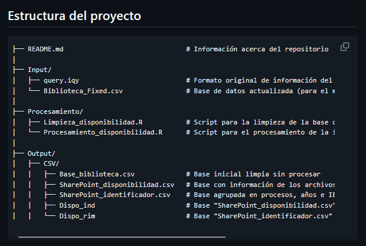

Estructura del repositorio

# 2. Informe Reportes y Seguimiento Denuncias

Norma de Carácter General N°4

**Algunas informaciones:**

*Participación*

```
91 IES obligadas por norma a informar
69 IES entregaron el reporte (75,8% del total)
22 IES no entregaron el reporte (24,2% del total requerido)
```

*Denuncias*

```
175 denuncias identificadas
169 denuncias consideradas válidas
6 denuncias excluidas de los análisis (no válidas)
```

**Conclusión (breve)**: El análisis evidencia un nivel medio entrega de reportes. Se recomienda mejorar cumplimiento institucional e incorporar resultados de investigaciones y sanciones.

# Productos Relacionados

**Informe Reporte y seguimiento de denuncias NCG N°4**

Se realizó un informe que expone todos los resultados del análisis.

**Repositorio de Procesamiento Datos**

Con el fin de transparencia y reproductibilidad se comparte el repositorio de procesamiento que tuvo el proyecto. Formato Git

```
https://github.com/Juan-JAP/Sana-Convivencia
```

## 2.1 Informe Reporte y seguimiento denuncias NCG N°4

Se realizó un informe formato documento que recolecta la información consolidada de los reportes de denuncias recibidas por las IES.

**Partes:**

**1. Análisis General**: Indica los niveles de entrega del reporte y las cantidades totales de denuncias

**2. Análisis descriptivo específico**: Se exponen los resultados descriptivos de cada dimensión del reporte

**3. Análisis Correlacional**: Examinación de asociaciones entre variables de interés

**Anexos**: Listado de IES que entregan de reporte y presencia de denuncia, Detalle de datos de Reporte y seguimiento de denuncias recibidas y Detalle de casos descartados del análisis

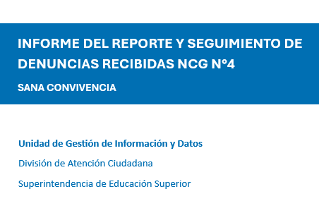

Portada Informe Reporte Denuncias NCG N°4

## 2.2 Repositorio de procesamiento de datos

> En este repositorio se encuentran los reportes enviados originales, los script R de limpieza, procesamiento y análisis, y las bases de datos resultantes.

**Nota:** Asimismo con el repositorio anterior, este se mantiene en un formato privado, por lo que se recomienda el mismo procedimiento.

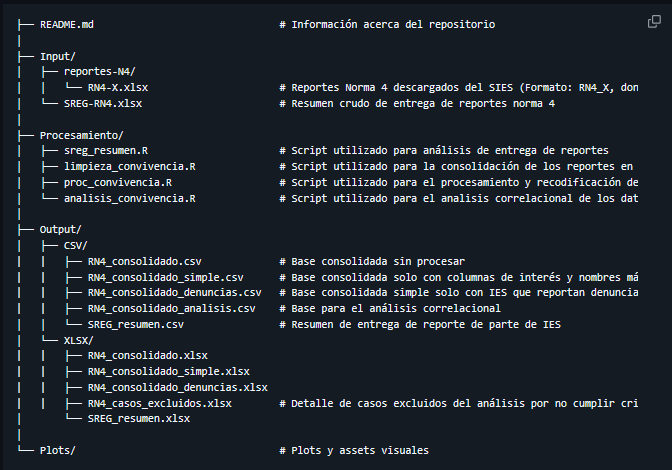

Estructura del repositorio

# 3 Informe Formulario Diagnóstico Ley 21.790

Yo Cuido, Yo Estudio

> Con este formulario, la SES diagnosticó la implementación de la Ley N.º 21.790, analizando avances y brechas institucionales para estudiantes cuidadores, mediante respuestas de 107 instituciones participantes.

**Participación**

```
124 IES invitadas a responder el formulario
107 Respuestas válidas de IES (86,3% del total)
```

**Conclusión (breve)**: La implementación de la Ley N.º 21.790 presenta avances, pero persisten brechas en confidencialidad, suspensión de estudios y flexibilización académica, que requieren atención prioritaria en la supervisión institucional.

# Productos Relacionados

**Informe Formulario Diagnóstico Ley 21.790**

Se realizó un informe que expone todos los resultados del análisis.

```
https://superinteducacion.sharepoint.com/:b:/s/DivisindeGestindeDatosyBuenasPrcticas/IQC-neN-wUR_T6OjC_wTNjzUAYZCBbWDQZ1Ae9hGMIpX04E?e=sdLnHK
```

**Dashboard**

Se ofrece una mejor visualización y búsqueda específica acerca de cada IES y sección del formulario

```
https://superinteducacion.sharepoint.com/:u:/s/DivisindeGestindeDatosyBuenasPrcticas/IQB1ZN6hGlglR73CNloGPxvEAe9malCnAFbew9zAgmEykV4?e=IuKDeB
```

## 3.1 Formulario Diagnóstico Ley 21.790

Se realizó un informe formato documento que contiene las secciones que se especifican en los formularios.

**Partes:**

**Caracterización de las respuestas**

**1. Marco Normativo Interno**

**2. Gobernanza e implementación institucional**

**3. Comunicación a docentes**

**4. Acreditación de la condición de estudiante cuidador/a**

**5. Suspensión, postergación y beneficios estudiantiles**

**6. Flexibilidad académica**

**7. Solicitudes recibidas**

**Anexos**

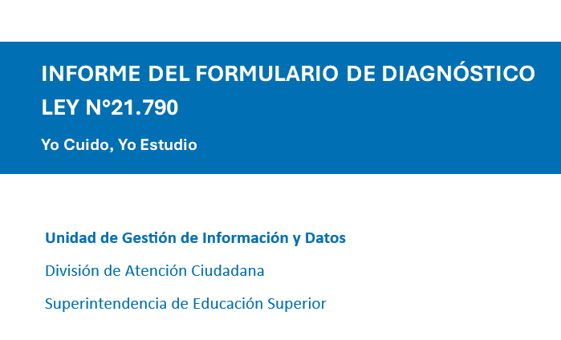

Portada Informe Diagnóstico Ley 21.790

Se produjo un Dashboard para tener una herramienta más navegable y específica para los resultados del formulario

**Nota:** Los apartados son los mismos del informe, pues ambos están basados en la organización temática de las baterías del formulario

[figure not shown]

Portada del Dashboard

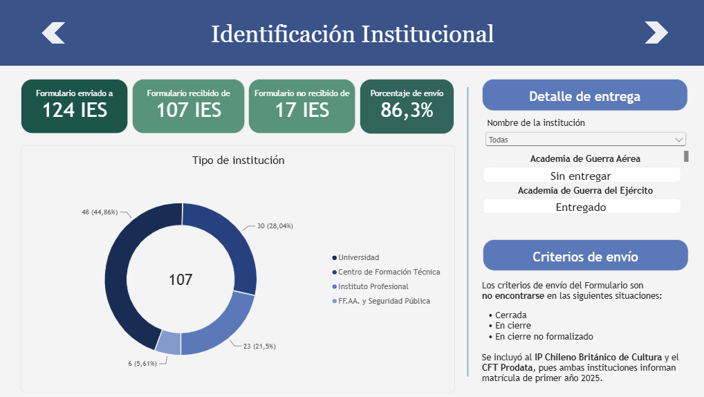

Pestaña de Dashboard

**¡Gracias por confiarme estos proyectos!**

Fue un placer haber trabajado con ustedes

Juan Prado

[figure not shown]

**Nota:** Este reporte fue realizado en Quarto ;)